# 隨機抽樣的方法

Methods of Random Sampling

Author

Tsai, Dai-Rong

- 研究背景: 某大學去年共有 2,000 名畢業生, 來自 26 個科系 (科系A-Z)
- 研究目的: 隨機抽樣 100 名畢業生, 推論該所大學學生畢業一年的就業率

  ```r
  graduate <- read.csv("data/graduate.csv")

  dim(graduate)
  ```

  ```
  [1] 2000    3
  ```

  ```r
  head(graduate)
  ```

  ```
    department id employment
  1          A  1          1
  2          A  2          1
  3          A  3          0
  4          A  4          0
  5          A  5          0
  6          A  6          1
  ```

  ```r
  table(graduate$department)
  ```

  ```
    A   B   C   D   E   F   G   H   I   J   K   L   M   N   O   P   Q   R   S   T
   57 109  55 103 109  30  76 101  71  59  98  73  70  67  49  95  53  20  62 104
    U   V   W   X   Y   Z
  111  84  85  99  78  82
  ```

  ```r
  N <- nrow(graduate)
  n <- 100

  set.seed(1) # 使每次執行程式時得到相同的隨機結果
  ```

# 1 隨機抽樣的方法

## 1.1 簡單隨機抽樣 (Simple Random Sampling)

```r
sample1_id <- sample(1:N, size = n)
sample1 <- graduate[sample1_id, ]

dim(sample1)
```

```
[1] 100   3
```

```r
head(sample1)
```

```
     department   id employment
1017          N 1017          0
1860          Y 1860          1
679           I  679          1
129           B  129          1
930           L  930          1
1533          U 1533          1
```

```r
# 就業率估計值
mean(sample1$employment)
```

```
[1] 0.66
```

## 1.2 系統性抽樣 (Systematic Sampling)

- 每隔 k 筆資料選擇一個樣本點
- 樣本均勻散佈在整個抽樣名單中
- 資料若有週期性, 估計結果會有偏差 (bias)

```r
# 計算抽樣間距
k <- N / n
k
```

```
[1] 20
```

```r
# 抽樣起始點
start <- sample(1:k, size = 1)
start
```

```
[1] 13
```

```r
# 從 start 開始，每隔 k 筆抽取一人
sample2_id <- seq(from = start, by = k, length.out = n)
sample2_id
```

```
  [1]   13   33   53   73   93  113  133  153  173  193  213  233  253  273  293
 [16]  313  333  353  373  393  413  433  453  473  493  513  533  553  573  593
 [31]  613  633  653  673  693  713  733  753  773  793  813  833  853  873  893
 [46]  913  933  953  973  993 1013 1033 1053 1073 1093 1113 1133 1153 1173 1193
 [61] 1213 1233 1253 1273 1293 1313 1333 1353 1373 1393 1413 1433 1453 1473 1493
 [76] 1513 1533 1553 1573 1593 1613 1633 1653 1673 1693 1713 1733 1753 1773 1793
 [91] 1813 1833 1853 1873 1893 1913 1933 1953 1973 1993
```

```r
sample2 <- graduate[sample2_id, ]

dim(sample2)
```

```
[1] 100   3
```

```r
head(sample2)
```

```
    department  id employment
13           A  13          0
33           A  33          1
53           A  53          0
73           B  73          1
93           B  93          1
113          B 113          1
```

```r
# 就業率估計值
mean(sample2$employment)
```

```
[1] 0.71
```

## 1.3 分層抽樣 (Stratified Sampling)

- 較小的分層 (strata) 可以增加抽出率, 以保障這些分層有足夠樣本數
- 各分層的樣本平均值進行加權平均, 以估計族群平均值
- 變異數比簡單隨機抽樣小

**Warning**

各分層樣本平均值之權重, 應該使用目標族群中各分層的比例, 而非抽出樣本的分層比例。

```r
# 計算目標族群中各科系人數
dept_count <- table(graduate$department)
dept_count
```

```
  A   B   C   D   E   F   G   H   I   J   K   L   M   N   O   P   Q   R   S   T
 57 109  55 103 109  30  76 101  71  59  98  73  70  67  49  95  53  20  62 104
  U   V   W   X   Y   Z
111  84  85  99  78  82
```

```r
# 計算各科系抽樣人數
# 此處將各科系抽出率設為一致 (n/N), 實際上各分層可以有不同抽出率
dept_sample_size <- round(dept_count * n / N)
dept_sample_size
```

```
A B C D E F G H I J K L M N O P Q R S T U V W X Y Z
3 5 3 5 5 2 4 5 4 3 5 4 4 3 2 5 3 1 3 5 6 4 4 5 4 4
```

```r
# round() 四捨五入之後可能造成總和不等於 100
sum(dept_sample_size)
```

```
[1] 101
```

```r
# 產生科系清單
dept_list <- unique(graduate$department)

# 初始化一個空的向量, 收集各科系所抽出的 ID
sample3_id <- c()

# 根據各科系指定的樣本數進行隨機抽樣
for(dept in dept_list) {
  # 找出該科系所有學生的資料列
  dept_id <- which(graduate$department == dept)

  # 從該科系隨機抽取指定人數
  dept_id_sampled <- sample(dept_id, size = dept_sample_size[dept])

  # 將各科系所抽出的 id 合併成一個向量
  sample3_id <- c(sample3_id, dept_id_sampled)
}

sample3 <- graduate[sample3_id, ]

# 查看 sample3 各科系人數是否與 dept_sample_size 一致
all.equal(table(sample3$department), dept_sample_size)
```

```
[1] TRUE
```

```r
dim(sample3)
```

```
[1] 101   3
```

```r
head(sample3)
```

```
    department  id employment
21           A  21          1
31           A  31          0
38           A  38          1
74           B  74          1
130          B 130          1
160          B 160          1
```

```r
# 就業率估計值
sum(tapply(sample3$employment, sample3$department, mean) * proportions(dept_count))
```

```
[1] 0.6632333
```

## 1.4 群集抽樣 (Cluster Sampling)

- 以群集 (cluster) 為單位隨機抽樣, 抽中的群集中所有成員皆作為樣本
- 若從抽中的群集成員中再進行隨機抽樣, 稱為 **二階段抽樣** (two-stage sampling)
- 節省研究經費及時間成本
- 變異數比簡單隨機抽樣大

```r
# 產生科系清單
dept_list <- unique(graduate$department)

# 隨機抽取 5 個科系
dept_selected <- sample(dept_list, size = 5)
sort(dept_selected)
```

```
[1] "F" "I" "Q" "T" "X"
```

```r
# 找出這 5 個科系的所有學生
cluster_id <- which(graduate$department %in% dept_selected)
length(cluster_id)
```

```
[1] 357
```

```r
# 從這些學生中隨機抽取 100 人
sample4_id <- sample(cluster_id, size = n)
sample4 <- graduate[sample4_id, ]

# 檢查 sample4 包含哪些科系
table(sample4$department)
```

```
 F  I  Q  T  X
 5 22 15 28 30
```

```r
dim(sample4)
```

```
[1] 100   3
```

```r
head(sample4)
```

```
     department   id employment
1248          Q 1248          1
1254          Q 1254          0
651           I  651          1
1811          X 1811          0
646           I  646          1
1788          X 1788          0
```

```r
# 就業率估計值
mean(sample4$employment)
```

```
[1] 0.7
```

# 2 信賴區間

```r
p <- mean(sample1$employment)
p + c(qnorm(0.025), qnorm(0.975)) * sqrt(p * (1-p) / n)
```

```
[1] 0.5671548 0.7528452
```

Q. 重複抽樣 100 次, 得到 100 個信賴區間, 有幾個區間會涵蓋就業率的母體真值 ?

```r
# 初始化一個空的矩陣, 包含 3 個 columns, 依序記錄:
#   (1) p 的估計值
#   (2) p 的信賴區間下界
#   (3) p 的信賴區間上界
p_rep <- matrix(nrow = 0, ncol = 3)

# 重複抽樣 100 次
for(i in 1:100) {
  sample1_id <- sample(1:N, size = n)
  sample1 <- graduate[sample1_id, ]

  p <- mean(sample1$employment)
  p_ci <- p + c(qnorm(0.025), qnorm(0.975)) * sqrt(p * (1-p) / n)

  # 合併每一次抽樣所計算出的 p 與 p_ci
  p_rep <- rbind(p_rep, c(p, p_ci))
}

dim(p_rep)
```

```
[1] 100   3
```

```r
head(p_rep)
```

```
     [,1]      [,2]      [,3]
[1,] 0.71 0.6210643 0.7989357
[2,] 0.71 0.6210643 0.7989357
[3,] 0.70 0.6101832 0.7898168
[4,] 0.66 0.5671548 0.7528452
[5,] 0.70 0.6101832 0.7898168
[6,] 0.60 0.5039818 0.6960182
```

```r
# 就業率的母體真值
p_true <- mean(graduate$employment)
p_true
```

```
[1] 0.7
```

```r
# 標準誤 (standard error)
p_se <- sqrt(p_true * (1 - p_true) / n)
p_se
```

```
[1] 0.04582576
```

```r
# 有幾個區間會涵蓋就業率的母體真值 ?
cover_or_not <- (p_true >= p_rep[, 2] & p_true <= p_rep[, 3])
sum(cover_or_not)
```

```
[1] 95
```

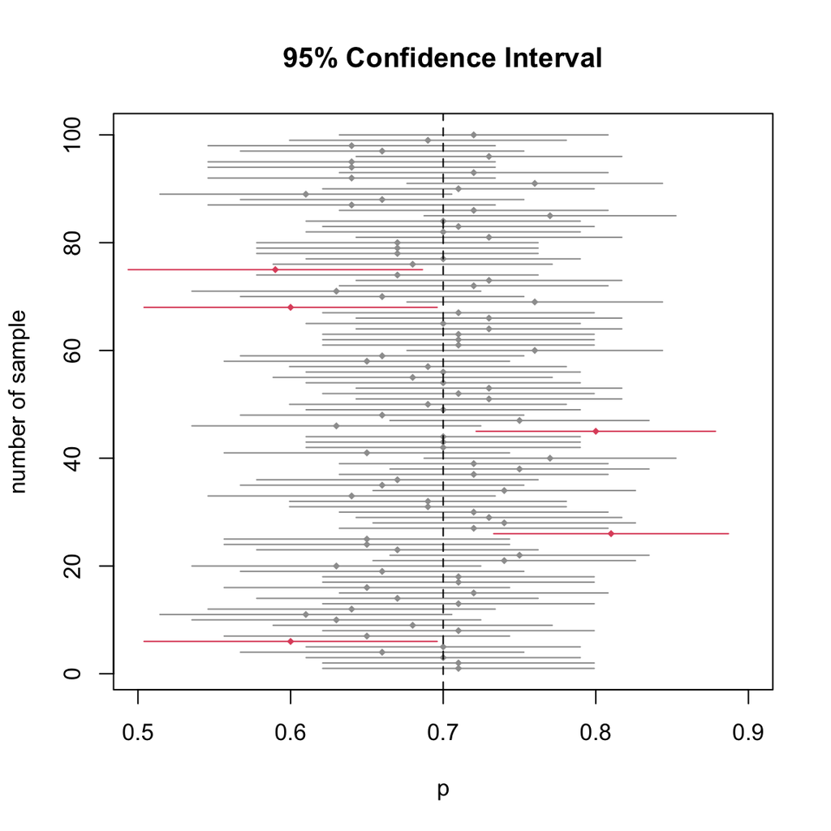

```r
plot(p_rep[, 1], 1:100, pch = 18, cex = 0.7, xlim = c(0.5, 0.9),
     col = ifelse(cover_or_not, 8, 2),
     main = "95% Confidence Interval",
     xlab = "p", ylab = "number of sample",)
segments(p_rep[, 2], 1:100, p_rep[, 3], 1:100,
         col = ifelse(cover_or_not, 8, 2))
abline(v = p_true, lty = 2)
```

# 3 中央極限定理

增加重複抽樣次數至 1000 次, 可更清楚描繪就業率的抽樣分布 (sampling distribution)。

```r
p_rep <- matrix(nrow = 0, ncol = 3)

for(i in 1:1000) {
  sample1_id <- sample(1:N, size = n)
  sample1 <- graduate[sample1_id, ]

  p <- mean(sample1$employment)
  p_ci <- p + c(qnorm(0.025), qnorm(0.975)) * sqrt(p * (1-p) / n)

  p_rep <- rbind(p_rep, c(p, p_ci))
}
```

```r
# 觀測值
c(Mean = mean(p_rep[, 1]), SE = sd(p_rep[, 1]))
```

```
     Mean        SE
0.6996900 0.0462054
```

```r
# 理論值
c(Mean = p_true, SE = p_se)
```

```
      Mean         SE
0.70000000 0.04582576
```

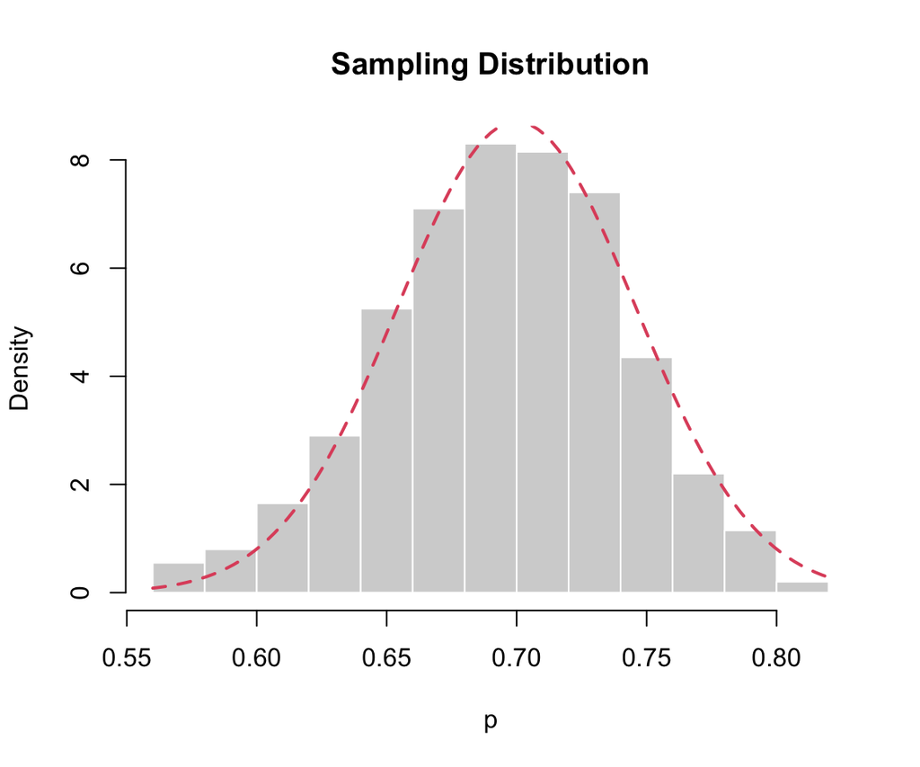

```r
hist(p_rep[, 1], prob = TRUE, border = "white",
     main = "Sampling Distribution", xlab = "p")
curve(dnorm(x, mean = p_true, sd = p_se), add = TRUE,
      col = 2, lwd = 2, lty = 2)
```